# Graphs

The examples shown here use a simple library around matplotlib. Later, matplotlib can be used directly for much more control of how graphs are displayed.

```python
# Install plot library using pip
import sys
!{sys.executable} -m pip install matplotlib
```

```python
# Move to the plot directory
%cd ../fields/graphs
```

```
/dave/software/codeplayfield/fields/graphs
```

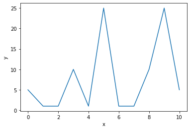

```python
from LibGraph.Graph import *

coinAmounts = [5, 1, 1, 10, 1, 25, 1, 1, 10, 25, 5]
displayLineGraph1D(coinAmounts, 'x', 'y')
```

The x and y labels are correct, but they don't mean much. There were 11 coins, so the x axis shows that there are 11 items numbered 0 to 10. The y axis is 0 to 25, so that is the coin amount. So improving the meaning of the labels gives the following.

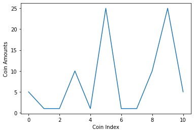

```python
coinAmounts = [5, 1, 1, 10, 1, 25, 1, 1, 10, 25, 5]
displayLineGraph1D(coinAmounts, 'Coin Index', 'Coin Amounts')
```

To make it easier to count the coins, each coin can be shown as a point. Notice that the amounts are in the same place, but lines are not connecting them.

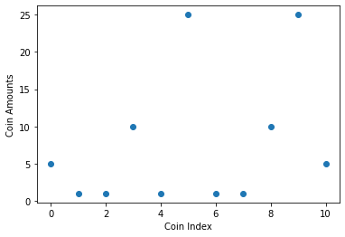

```python
coinAmounts = [5, 1, 1, 10, 1, 25, 1, 1, 10, 25, 5]
displayPointsGraph1D(coinAmounts, 'Coin Index', 'Coin Amounts')
```

Python has an easy way to sort the values. This makes it easier to add the amounts together.

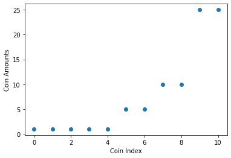

```
sum of coins 85
```

```python
coinAmounts = [5, 1, 1, 10, 1, 25, 1, 1, 10, 25, 5]
sortedCoinAmounts = sorted(coinAmounts)
displayPointsGraph1D(sortedCoinAmounts, 'Coin Index', 'Coin Amounts')
print('sum of coins', sum(coinAmounts))
```

There is a different kind of graph that can show the count of each kind of coin. This graph shows that there are 5 one cent values, 2 five cent values, etc.

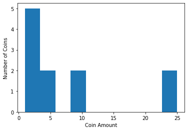

```python
coinAmounts = [5, 1, 1, 10, 1, 25, 1, 1, 10, 25, 5]
displayHistogram(coinAmounts, 'Coin Amount', 'Number of Coins')
```

The "bins" are figured out automatically, but they don't work well for coins. In this case, it looks like the bins are about 2.5 wide.

The histogram works by figuring out which values go into each bin. For the following example, the bins are defined. The values between 0.5 and 1.5 will go into the second bin. Then there are zero values that are between 1.5 and 4.5 because the coin amounts jump from 1 cents to 5 cents.

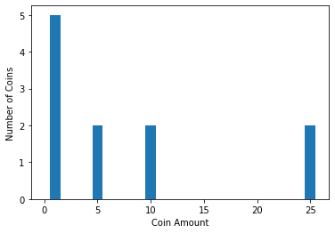

```python
coinAmounts = [5, 1, 1, 10, 1, 25, 1, 1, 10, 25, 5]
bins = [0, 0.5, 1.5, 4.5, 5.5, 9.5, 10.5, 24.5, 25.5]
displayHistogram(coinAmounts, 'Coin Amount', 'Number of Coins', bins)
```

## More Complex Data

The first value in each pair (tuple) is the coin amount, then second value is the year it was made.

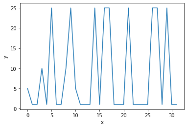

```python
from LibGraph.Graph import *

coins = [
(5, 2004), (1, 2001), (1, 1990), (10, 2020), (1, 1990), (25, 1999), (1, 2003),
(1, 2014), (10, 2016), (25, 1979), (5, 2015), (1, 2016), (1, 2020), (1, 2012),
(25, 2002), (1, 1976), (25, 1989), (25, 2013), (1, 2012), (1, 1983), (1, 2012),
(25, 2018), (1, 2019), (1, 1978), (1, 2019), (1, 1998), (25, 2006), (25, 2019),
(1, 2020), (25, 1990), (1, 2004), (1, 2015)]

coinAmounts = []
for pair in coins:
    coinAmounts.append(pair[0])    # Get the first value (index=0) of every pair
displayLineGraph1D(coinAmounts, 'x', 'y')
```

Instead of using 3 lines to get the amounts of the coins, the following line could be used.

```python
coinAmounts = [coin[0] for coin in coins]
```